# Pandas-Bootcamp-Part14

https://www.udemy.com/course/the-ultimate-pandas-bootcamp-advanced-python-data-analysis/learn/lecture/19711858#overview

```python
import sys
```

```python
sys.version
```

```
'3.8.3 (default, Jul  2 2020, 17:30:36) [MSC v.1916 64 bit (AMD64)]'
```

#### Agenda:

```
- Fundamental datatypes
- Containers
- Iteration and Membership
- Control Flow : if, else , elif , and for, while loops
- Comprehensions
- Function Declarations and Anonymous Functions
- Modules and More
```

### Data Types

Data Types are foundational in computer Programming because they help the computer in determining how a value will be stored in memory and what operations can and cannot be performed on that given value.

Each Object in Python will be associated with a Type. It could either be a Fundamental datatype, as listed below.

int , float , bool , str , tuple , list , set , dict

There is also a Data type called "None"

None represents the absence of a value.

And there could also be specialized Data Types.

Each Object in Python will be associated with a Type. The Type will determine what properties and behaviours apply to that object.

```python
#To know the type of the object we use built-in type() method
type(2)
```

```
int
```

```python
type('Andy')
```

```
str
```

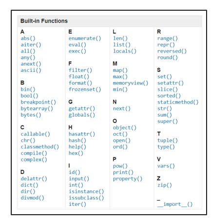

```python
#abs()
abs(-2.2222)
```

```
2.2222
```

```python
#print()
print("Hey there!")
```

```
Hey there!
```

#### Variables

Variables are pointers to a place in memory that stores or holds a value and they have a Name or Identifier.

- In other words , they bind a value to a name

```python
username = "Anna"
```

```python
username
```

```
'Anna'
```

Variables are one of the key foundational Building Blocks .

Variable Naming :

```
- Variable names should be Descriptive
- Variables are Case Sensitive
- function names should be lowercase, with words separated by underscores as necessary to improve
readability. Variable Names follow the same convention as the function names.
- lowercase is also called snake-case
```

#### Reserved Keywords in Python

```python
import keyword
keyword.kwlist
```

```
['False',
 'None',
 'True',
 'and',
 'as',
 'assert',
 'async',
 'await',
 'break',
 'class',
 'continue',
 'def',
 'del',
 'elif',
 'else',
 'except',
 'finally',
 'for',
 'from',
 'global',
 'if',
 'import',
 'in',
 'is',
 'lambda',
 'nonlocal',
 'not',
 'or',
 'pass',
 'raise',
 'return',
 'try',
 'while',
 'with',
 'yield']
```

These keywords cannot be assigned to anything .

However , you can alter these keywords and assign.

- example : return_data or raise_exception .....and so on

#### Multiple variable Assignments

```python
user_name , user_age , user_gender = 'Andy' , 39 , 'Male'
```

```python
print(user_name)
print(user_age)
print(user_gender)
```

```
Andy
39
Male
```

#### Arithmetic and Augmented Assignment Operators

- basic arithmetics with + , - , * , /
- Augmented Assignment Operators
- Other operators worth knowing about : **, %
- Operator Precedence PEMDAS

```python
num1 = 39
num2 = 40
num1 + num2
```

```
79
```

```python
num1 * num2
```

```
1560
```

```python
num1 / num2
```

```
0.975
```

#### Augmented Assignment Operators

```python
counter = 1
```

```python
#task : Increment the Counter by 1
counter = counter + 1
```

```python
counter
```

[output not shown]

```python
counter
```

```
2
```

```python
counter
```

[output not shown]

```python
#We can multiply counter by 2
```

```python
counter *= 2
```

```python
#counter value was 3 , 3X2 = 6
counter
```

```
6
```

Other operators worth knowing worth knowing about : ** , %

Exponentiation Operator : **

```python
# 2 Cubed
#We brin 2 to the 3rd power
2 ** 3
```

```
8
```

```python
#2 to the second power is 4
2**2
```

```
4
```

```python
#2 to the 4th power
2**4
```

```
16
```

#### Other operator is the Modulo Operator

Modulo operator gives us the remainder when a given number is divided by another number

```python
#The remainder when 5 is divided by 2 is 1
5 % 2
```

```
1
```

#### Modulo operator can help us check if a given number is Even or Odd

```python
#To check whether its evenly divisible by 2
#Meaning : When we divide it by 2 , the remainder is 0 , so we can conclude its EVEN

12312312 % 2
```

```
0
```

```python
12312311 % 2  #ODD
```

```
1
```

#### Operator Precedence : PEMDAS

Certain operators take precedence over others

#### PEMDAS : Parenthesis , Exponentiation , Multiplication , Division , Addition , Subtraction

```python
(2 - 1) * 4 ** 2
```

```
16
```

```python
1 * 4 ** 2
```

```python
1 * 16
```

```
16
```

### Ints and Floats

#### Integers :

- Integers are simply whole (complete) numbers , with no fractional value
- Useful for Counting

#### Floats :

- Floats are real numbers with a fractional Value.
- Dividing one integer by another gives us a Float, or Floating point number
- In general, any operation involving a Float , produces a Float

```python
4 / 10
```

```
0.4
```

1. is same as 2.0

```python
2.
```

```
2.0
```

```python
2.0
```

```
2.0
```

### Ints and floats

- Any operation between an Int and a Float always produces a Float

```python
1.0 + 1
```

```
2.0
```

We convert Floats to Ints and vice versa

```python
type(3.0)
```

```
float
```

```python
int(3.0)
```

```
3
```

```python
type(100)
```

```
int
```

```python
float(100)
```

```
100.0
```

#### Floating Point Numbers are approximations

Computers store Floating Point Numbers as binary (base 2) fractions.

For example :

- Lets say we have 0.1
- That is 1/10

```python
1 / 10
```

```
0.1
```

This is a base 10 Number system

But , to a computer everything is binary. A computer needs to break this down and map it to a base 2 representation. Its impossible to represent 0.1 in binary, so it stores something like

```python
#expected Output is 0.3
#But we get a wierd looking output
#This is something to be aware of if you find this result surprising
0.1 + 0.2
```

```
0.30000000000000004
```

#### Booleans and Comparison Operators

- a bool represents the notion of True or False
- We could generate bools using comparison operators
- and combine them using Logical operators

```python
type(True)
```

```
bool
```

```python
type(False)
```

```
bool
```

- We could generate booleans using Comparison operators

```python
age_of_worker  = 43
retirement_age = 64
```

```python
#We want to see whether this worker is ready to retire
#Comparing "age_of_worker" and "retirement_age"
age_of_worker >= retirement_age
```

```
False
```

```python
#Not Equal to operator
retirement_age != age_of_worker
```

```
True
```

```python
retirement_age == age_of_worker #Comparison Operator
```

```
False
```

'=' is an assignment operator

#### Combining bools using Logical Operators

```python
True or True
```

```
True
```

```python
True or False
```

```
True
```

```python
True and False
```

```
False
```

```python
False and False
```

```
False
```

```python
not False
```

```
True
```

```python
not True
```

```
False
```

### Strings

String is an ordered sequence of characters that could include letters , numbers , symbols , punctuation, etc

```python
type('ghsaghsahg 678798899 !!!!!! ------ +++++')
```

```
str
```

```python
"Let's code 'Pandorably'"
```

```
"Let's code 'Pandorably'"
```

```python
'''This is the first line of the string
    this is the second
    and this is the third'''
```

```
'This is the first line of the string \n    this is the second\n    and this is the third'
```

#### Concatenation : Combine Strings with + Operator

```python
'Andy' + 'Bek'
```

```
'AndyBek'
```

```python
('Andy' + 'Bek').title()
```

```
'Andybek'
```

```python
('Andy' + ' Bek').title()
```

```
'Andy Bek'
```

#### String Repetition

```python
#This is also called Polymorphism
```

```python
"<>" * 60
```

```
'<><><><><><><><><><><><><><><><><><><><><><><><><><><><><><><><><><><><><><><><><><><><><><><><><><><><><><><><><><><><>'
```

```python
"~~~Keep smiling~~~" * 6
```

```
'~~~Keep smiling~~~~~~Keep smiling~~~~~~Keep smiling~~~~~~Keep smiling~~~~~~Keep smiling~~~~~~Keep smiling~~~'
```

### METHODS

Methods are very similar to functions

We pass arguments to a Function , example below:

```python
type('python')
```

```
str
```

```python
type(23)
```

```
int
```

```python
type(8.9)
```

```
float
```

#### String Methods

Methods are called on an object

```python
'python'.upper()
```

```
'PYTHON'
```

```python
'PYTHON'.lower()
```

```
'python'
```

```python
#isalpha() : if the string only contains Alphabetical charachters
'python'.isalpha()
```

```
True
```

```python
'python898'.isalpha()
```

```
False
```

```python
'python'.startswith('py')
```

```
True
```

```python
'python'.endswith('ON')  #because it is case sensitive
```

```
False
```

```python
'python'.endswith('on')
```

```
True
```

```python
'python'.upper().endswith('ON')
```

```
True
```

#### format method

value substitutions with .format()

```python
x = 3.9
```

```python
"We will be using Python V{}".format(x)
```

```
'We will be using Python V3.9'
```

```python
#Curly braces are the Placeholder variables.
```

```python
"we will be using Python V{py_v}, Pandas V{pa_v} , Numpy V{na_v}".format(py_v = 3.8 ,pa_v = ' 1.2.3' , na_v = ' 5.6.7')
```

```
'we will be using Python V3.8, Pandas V 1.2.3 , Numpy V 5.6.7'
```

### Lists

Lists are ordered sequences of elements

```python
students = ['Andrew' , 'Brie' , 'Cynthia']
```

```python
students[1]
```

```
'Brie'
```

Sequence of Indices ( List Slicing)

```python
students[0:2]
```

```
['Andrew', 'Brie']
```

```python
students[-1] #Last element
```

```
'Cynthia'
```

```python
students[:]
```

```
['Andrew', 'Brie', 'Cynthia']
```

### LISTS VS Strings

```python
students[0]
```

```
'Andrew'
```

```python
py = 'Python'
```

```python
py[0]
```

```
'P'
```

Lists are Mutable , Strings are Immutable

```python
py
```

```
'Python'
```

We can access any letter in the String but we cannot alter or change it

```python
py[0] = 'lk'
```

```
---------------------------------------------------------------------------
TypeError                                 Traceback (most recent call last)
<ipython-input-136-fa18656f4ab5> in <module>
----> 1 py[0] = 'lk'

TypeError: 'str' object does not support item assignment
```

We can very well assign a new string to the variable "py"

```python
py = 'numpy'
```

```python
students
```

```
['Andrew', 'Brie', 'Cynthia']
```

```python
students[-1]
```

```
'Cynthia'
```

```python
students[-1] = 'John'
```

```python
students
```

```
['Andrew', 'Brie', 'John']
```

### List Methods and Functions

```python
ages = [ 23 , 39 , 12 , 12.1]
```

```python
len(ages)
```

```
4
```

```python
min(ages)
```

```
12
```

```python
sorted(ages)
```

```
[12, 12.1, 23, 39]
```

```python
ages
```

```
[23, 39, 12, 12.1]
```

```python
sorted(ages , reverse = True)
```

```
[39, 23, 12.1, 12]
```

```python
ages.append(24)
```

```python
ages
```

```
[23, 39, 12, 12.1, 24]
```

```python
#Remove Last Item
ages.pop(-1)
```

```
24
```

```python
ages
```

```
[23, 39, 12, 12.1]
```

#### str.join(list) to join all elemnts of a LIST into a String

```python
students
```

```
['Andrew', 'Brie', 'John']
```

```python
#We specify the separator
#We are about to perform JOIN operaion between diff elements of a List
#We start by specifying what we want these items to be separated by
#If we dont want them to be separated by anything , we start with an Empty string
#It results in one single str object
#Here we went from a List of elements to asingle String
```

```python
''.join(students)
```

```
'AndrewBrieJohn'
```

```python
','.join(students)
```

```
'Andrew,Brie,John'
```

```python
type(','.join(students))
```

```
str
```

### Tuples

Tuples are ordered and Immutable

```python
user_data = ('Ronald' , 9)
```

```python
type(user_data)
```

```
tuple
```

```python
user_data[0]
```

```
'Ronald'
```

```python
user_data[-1]
```

```
9
```

We use tuples when we need to store values that are Closely related together

```python
user_data = ('Ronald', 9,  11)
```

```python
user_data2 ={'col1': [1, 2], 'col2': [3, 4]}
```

```python
user_data2 ={'col1': [1], 'col2': [2]}
```

```python
import pandas as pd
import numpy as np
```

```python
pd.DataFrame(user_data2)
```

[output not shown]

### SET

Unorederd container of only UNIQUE values

```python
degrees = {'BSC' , 'MA' , 'PHD'}
```

```python
degrees
```

```
{'BSC', 'MA', 'PHD'}
```

```python
degrees = {'BSC' , 'MA' , 'PHD' , 'PHD'}
```

```python
degrees
```

```
{'BSC', 'MA', 'PHD'}
```

SET is an unordered Collection tht means , we cannot index a SET

```python
degrees[0]
```

```
---------------------------------------------------------------------------
TypeError                                 Traceback (most recent call last)
<ipython-input-200-b0d03deeefc9> in <module>
----> 1 degrees[0]

TypeError: 'set' object is not subscriptable
```

```python
for i in degrees:
    print(i)
```

```
MA
PHD
BSC
```

```python
[i for i in degrees]
```

```
['MA', 'PHD', 'BSC']
```

```python
degrees
```

```
{'BSC', 'MA', 'PHD'}
```

```python
#Add an element
degrees.add('BA')
```

```python
degrees.discard('MA')
```

```python
degrees
```

```
{'BA', 'BSC', 'PHD'}
```

```python
degrees2
```

```
{'BA', 'MA', 'PHD'}
```

#### Intersection

```python
degrees.intersection(degrees2) #All elements common in both
```

```
{'BA', 'PHD'}
```

#### Union

```python
degrees.union(degrees2) #This will be a bigger set , with all elements in both
```

```
{'BA', 'BSC', 'MA', 'PHD'}
```

#### difference

- A difference B : All the elements in A that are not in B
- B difference A : All the elements in B that are not in A

```python
degrees
```

```
{'BA', 'BSC', 'PHD'}
```

```python
degrees2
```

```
{'BA', 'MA', 'PHD'}
```

```python
degrees.difference(degrees2)
```

```
{'BSC'}
```

```python
#BSC is not there in degrees2
```

```python
degrees2.difference(degrees)
```

```
{'MA'}
```

```python
#MA is not there in degrees
```

### Dictionaries

https://www.udemy.com/course/the-ultimate-pandas-bootcamp-advanced-python-data-analysis/learn/lecture/19712284#overview

Dictionaries are Mutable , Unordered

- They are built using Key : Value Pairs
- values are accessed using [] or with .get()
- Adding and Removing elements : dict[key] = value and dict.pop(key)

```python
#Student Scores Dictionary will have "Student Names" and their respective Scores
#We have 3 key:value pairs
student_scores = {'Andrew' : 94 , 'Jessica' : 96 , 'Brie' : 79}
```

```python
type(student_scores)
```

```
dict
```

- In other Programming Languages , a Dict is also known as a Hash table
- or a Hash Map

#### Accessing Values from Dictionaries

```python
#To access Jessica's Scores
student_scores['Jessica']
```

```
96
```

```python
student_scores
```

```
{'Andrew': 94, 'Jessica': 96, 'Brie': 79}
```

```python
#If we try to access a Key that does not exist , Python throws a "Key" Error
student_scores['Andy']
```

```
---------------------------------------------------------------------------
KeyError                                  Traceback (most recent call last)
<ipython-input-5-15787104e84c> in <module>
      1 #If we try to access a Key that does not exist , Python throws a "Key" Error
----> 2 student_scores['Andy']

KeyError: 'Andy'
```

```python
#get() is an alternative  to Square brackets
#if we try to access a value that is not present , get() simply returns "None" and the Program continues
student_scores.get('Andrew')
```

```
94
```

```python
student_scores.get('Joe')
```

```python
print(student_scores.get('Joe'))
```

```
None
```

#### Adding and Removing Key : Value Pairs from a Dictionary

```python
student_scores
```

```
{'Andrew': 94, 'Jessica': 96, 'Brie': 79}
```

We want to add "Tom" who got 69 Score to the Dictionary

```python
student_scores['Tom'] = 69
```

```python
student_scores
```

```
{'Andrew': 94, 'Jessica': 96, 'Brie': 79, 'Tom': 69}
```

```python
#Remove a Key:value pair
student_scores.pop('Brie')
```

```
79
```

```python
student_scores
```

```
{'Andrew': 94, 'Jessica': 96, 'Tom': 69}
```

### Closer look at the Keys and Values

The Values in the Dict could be any value or container object, even other Dictionaries

```python
#Lets say "Andrew" took just one exam and scored 96
#Jesscia took multiple exams and scored 96 and 93
#Now each key is associated with a different DataType
#Andrew is int
#Jessica is Python List
#Tom is Python Dict again (Which is a nested data structure)
student_scores2 = {
    'Andrew' : 96,
    'Jessica' : [96, 93],
    'Tom' : {
        'bio' : 94,
        'chem' : 84,
        'Phys' : 79
    }
}
```

```python
student_scores = {'Andrew' : 94 , 'Jessica' : 96 , 'Brie' : 79 ,'Andrew' : 94 , 'Jessica' : 96 , 'Brie' : 77}
```

```python
student_scores
```

```
{'Andrew': 94, 'Jessica': 96, 'Brie': 77}
```

```python
#Dictionary is not taking Duplicate keys
```

```python
#Creating DataFrame
student_scores = {'Andrew' : [94] , 'Jessica' : [96] , 'Brie' : [79]}
```

```python
import pandas as pd
import numpy as np
pd.DataFrame(student_scores)
```

|  | Andrew | Jessica | Brie |
| --- | --- | --- | --- |
| 0 | 94 | 96 | 79 |

```python
student_scores2 = {
    'Andrew' : [96],
    'Jessica' : [96, 93],
    'Tom' : {
        'bio' : [94],
        'chem' : [84],
        'Phys' : [79]
    }
}
```

```python
student_scores2
```

```
{'Andrew': [96],
 'Jessica': [96, 93],
 'Tom': {'bio': [94], 'chem': [84], 'Phys': [79]}}
```

```python
len(student_scores2)
```

```
3
```

```python
pd.DataFrame(student_scores2)
```

[output not shown]

```python
student_scores2 = {
    'Andrew' : {
        'bio' : [94],
        'chem' : [84],
        'Phys' : [79],
        'Hind' : [44]
    },
    'Jessica' : {
        'bio' : [94],
        'chem' : [84],
        'Phys' : [79]
    },
    'Tom' : {
        'bio' : [94],
        'chem' : [84],
        'Phys' : [79]
    }
}
```

```python
student_scores2
```

```
{'Andrew': {'bio': [94], 'chem': [84], 'Phys': [79], 'Hind': [44]},
 'Jessica': {'bio': [94], 'chem': [84], 'Phys': [79]},
 'Tom': {'bio': [94], 'chem': [84], 'Phys': [79]}}
```

```python
pd.DataFrame(student_scores2 )
```

|  | Andrew | Jessica | Tom |
| --- | --- | --- | --- |
| bio | [94] | [94] | [94] |
| chem | [84] | [84] | [84] |
| Phys | [79] | [79] | [79] |
| Hind | [44] | NaN | NaN |

#### Creating "Index" column , starting value : 1

```python
student_scores = {'Andrew' : [94 , 78, 99 , 100 , 101 ,200 ] ,
                  'Jessica' : [94 , 78, 99 , 100 , 101 ,200] ,
                  'Brie' : [94 , 78, 99 , 100 , 101 ,200] ,
                 }
```

```python
test = pd.DataFrame(student_scores)
```

```python
test
```

|  | Andrew | Jessica | Brie |
| --- | --- | --- | --- |
| 0 | 94 | 94 | 94 |
| 1 | 78 | 78 | 78 |
| 2 | 99 | 99 | 99 |
| 3 | 100 | 100 | 100 |
| 4 | 101 | 101 | 101 |
| 5 | 200 | 200 | 200 |

```python
test.index+1
```

```
RangeIndex(start=1, stop=7, step=1)
```

```python
test['index'] = test.index+1
```

```python
test
```

|  | Andrew | Jessica | Brie | index |
| --- | --- | --- | --- | --- |
| 0 | 94 | 94 | 94 | 1 |
| 1 | 78 | 78 | 78 | 2 |
| 2 | 99 | 99 | 99 | 3 |
| 3 | 100 | 100 | 100 | 4 |
| 4 | 101 | 101 | 101 | 5 |
| 5 | 200 | 200 | 200 | 6 |

In Python, if the value of an object cannot be changed over time, then it is known as immutable. Once created, the value of these objects is permanent.

#### Dictionary methods:

```
- keys()
- values()
- items()
```

These are very useful when we iterate through our Dictionary content.

```python
student_scores = {'Andrew' : 94 , 'Jessica' : 96 , 'Brie' : 79}
```

```python
student_scores
```

```
{'Andrew': 94, 'Jessica': 96, 'Brie': 79}
```

```python
student_scores.keys()
```

```
dict_keys(['Andrew', 'Jessica', 'Brie'])
```

```python
student_scores.values()
```

```
dict_values([94, 96, 79])
```

```python
student_scores.items()
```

```
dict_items([('Andrew', 94), ('Jessica', 96), ('Brie', 79)])
```

```python
#items() returns a collection of Key : Value pairs as Tuples
```

```python
type(student_scores.keys())
```

```
dict_keys
```

```python
#Note : this ia a dict_keys object not a regular List
```

```python
type(student_scores.values())
```

```
dict_values
```

```python
type(student_scores.items())
```

```
dict_items
```

Dictionaries are Mutable and Unordered

- When we access our Dictionary , its not necessary that we will get it in the same order

### Membership Operators : "in" and "not in"

If a given value or an item is contained in another data structure

```python
student_scores
```

```
{'Andrew': 94, 'Jessica': 96, 'Brie': 79}
```

```python
'Brandon' in student_scores
```

```
False
```

```python
"Andrew" in student_scores
```

```
True
```

```python
'Andrew' not in student_scores
```

```
False
```

```python
first_name = "Andrew"
```

```python
'rew' in first_name
```

```
True
```

```python
#Strings are immutable
first_name
```

```
'Andrew'
```

```python
first_name.replace('rew' , 'ooop')
```

```
'Andooop'
```

```python
first_name #first_name is still "Andrew"
```

```
'Andrew'
```

```python
#After assignment
first_name = first_name.replace('rew' , 'ooop')
```

```python
first_name
```

```
'Andooop'
```

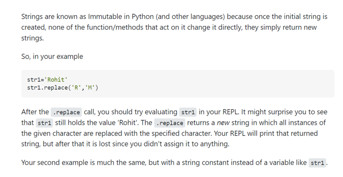

Membership checking is Case Sensitive

```python
first_name  = "Andrew"
```

```python
"AND" in first_name
```

```
False
```

```python
"And" in first_name
```

```
True
```

```python
"and" in first_name
```

```
False
```

```python
#Pandas has contains method
#Python has "in" operator
```

### Flow Control : if , else , else if

When we want to control WHICH part of the code gets executed WHEN

So, "condition" should evaluate to Boolean

Below: If student_1 {Exam Score} is greater than 70 , we want to append it to the "passed" list

```python
passed = []
failed = []

student_1 = {'name' : 'Jess' , 'exam_score' : 72 , 'attendance' : True}
student_2 = {'name' : 'Bian' , 'exam_score' : 90 , 'attendance' : True}
student_3 = {'name' : 'Lola' , 'exam_score' : 64 , 'attendance' : False}
```

```python
if student_1.get('exam_score') > 70:
    passed.append(student_1)
```

```python
passed
```

```
[{'name': 'Jess', 'exam_score': 72, 'attendance': True}]
```

```python
if student_2.get('exam_score') > 70:
    passed.append(student_2)
else:
    failed.append(student_2)
```

```python
passed
```

```
[{'name': 'Jess', 'exam_score': 72, 'attendance': True},
 {'name': 'Bian', 'exam_score': 90, 'attendance': True}]
```

```python
#Above , since the condition was met , "else" never got executed
```

```python
passed = []
failed = []

student_1 = {'name' : 'Jess' , 'exam_score' : 72 , 'attendance' : True}
student_2 = {'name' : 'Bian' , 'exam_score' : 90 , 'attendance' : True}
student_3 = {'name' : 'Lola' , 'exam_score' : 64 , 'attendance' : False}
```

```python
if student_3.get('exam_score') > 70:
    passed.append(student_3)
#Now we check if student score is less than 70 but greater than 65 and  attendance equal to True then...
elif student_3.get('exam_score') > 65 and attendance.get('attendance') == True:
    passed.append(student_3)
else:
    failed.append(student_3)
```

```python
passed
```

```
[]
```

```python
failed
```

```
[{'name': 'Lola', 'exam_score': 64, 'attendance': False}]
```

- Both these conditions were not met by student_3
- student_3.get('exam_score') > 70:
- student_3.get('exam_score') > 65 and attendance.get('attendance') == True:
- Hence he failed

### FOR Loops

#### FOR Loops help us execute a block of code multiple times

Python has two types of Loops : "For loop" and "While Loop"

- For loops help us iterate over a collection and execute a Block of code for each iteration

```python
should_greet =  True
greetings = ['hey, welcome' , 'this is Python' , 'Pandas is coming soon']
language = 'python'

if should_greet:
    print(greetings[0])
    print(greetings[1])
    print(greetings[2])
```

```
hey, welcome
this is Python
Pandas is coming soon
```

```python
#greeting is the iteration variable and "greetings" is the iterable
#Iterables are elements which return each element at a time
for greeting in greetings:
    print(greeting)
```

```
hey, welcome
this is Python
Pandas is coming soon
```

### range

#### range() is an immutable sequence of numbers

range accepts a start , a stop and a step argument

```python
range(3 , 10)
```

```
range(3, 10)
```

```python
list(range(3 , 10))
```

```
[3, 4, 5, 6, 7, 8, 9]
```

```python
list(range(0 , 10 , 2))
```

```
[0, 2, 4, 6, 8]
```

```python
how_many_times = 6

for i in range(how_many_times):
    print('hi')
```

```
hi
hi
hi
hi
hi
hi
```

### While Loop

For loops execute a block of code a definite number of times whereas while loop repeats an indefinite number of times, until a condition is met.

- balance = 2000
- next_round_cost = 42.34
- games_played = 0

Q. How many rounds we can play if the cost doubles each time and we have a balance of 2000? (The cost doubles each time the game is played)

```python
balance = 2000
next_round_cost = 42.34
games_played = 0
```

```python
#Condition is checking whether we have enough money to play the next round
#If we do, then , games_played should be incremented by 1
#Since the cost is doubling will will double the "next_round_cost"
#We will subtract the balance before we double it for the next round, so our balance reflects whats left

while balance > next_round_cost:
    print(balance)
    games_played += 1
    #balance -= next_round_cost
    balance = balance - next_round_cost
    print(balance)
    next_round_cost *= 2
```

```
2000
1957.66
1957.66
1872.98
1872.98
1703.62
1703.62
1364.8999999999999
1364.8999999999999
687.4599999999998
```

```python
#WE will check the games played
games_played
```

```
5
```

```python
#After 5 games played , thenext_round_cost was :
next_round_cost
```

```
1354.88
```

```python
#How much we had in our balance
balance
```

```
687.4599999999998
```

- So we can no more meet the criteria and we stop playing
- If we fail to decrease the balance , the balance will never change and it will be an infinite loop
- Whenever using while loop make sure , the body of the Loop is modifying some part of the condition

### Break and Continue

break : exits out of a loop

```python
greetings2 = ['hey' , 'hello' , 'stop' , 'wats up' , 'hey,let me tell you a story' , 'hey there' , 'whats new?']
```

```python
for greeting in greetings2:
    print(greeting)
```

```
hey
hello
stop
wats up
hey,let me tell you a story
hey there
whats new?
```

```python
#We want to break as soon as we come across the word stop
#'stop' is not printed because greeting == 'stop' evaluates to True
for greeting in greetings2:
    if greeting == 'stop':
        break
    else:
        print(greeting)
```

```
hey
hello
```

```python
greetings2
```

[output not shown]

```python
#continue skips a single Iteration
#Below  we do not want to print really long greetings
#'let me tell you a story' is skipped
for greeting in greetings2:
    if len(greeting) > 11:
        continue
    else:
        print(greeting)
```

```
hey
hello
stop
wats up
hey there
whats new?
```

### Zipping Iterables

```python
names = ['Andrew' , 'Ben' , 'Nick' , 'Jonas']
score = [100 , 90 , 74 , 84]
```

Zip creates an iterable , (a zip object ) combining values from other iterables

```python
#We are zipping both the list values togeher
#This creates a zip object
zip(names , score)
```

```
<zip at 0x15231cd2c40>
```

```python
list(zip(names , score))
```

```
[('Andrew', 100), ('Ben', 90), ('Nick', 74), ('Jonas', 84)]
```

```python
#This is very useful in iterating:
for i in zip(names , score):
    print(i)
```

```
('Andrew', 100)
('Ben', 90)
('Nick', 74)
('Jonas', 84)
```

```python
#We can unpack the zip object
#We know that the zip object produces a sequence of tuples
for i , j in zip(names , score):
    print(i , ":" , j)
```

```
Andrew : 100
Ben : 90
Nick : 74
Jonas : 84
```

```python
for student_names , student_scores in zip(names , score):
    print(student_names)
```

```
Andrew
Ben
Nick
Jonas
```

```python
for student_names , student_scores in zip(names , score):
    print("{} got a {} on the exam".format(student_names , student_scores))
```

```
Andrew got a 100 on the exam
Ben got a 90 on the exam
Nick got a 74 on the exam
Jonas got a 84 on the exam
```

#### Can be used in building a DataFrame

```python
pd.DataFrame(list(zip(names , score)) , columns = ['Student_Name' , 'Student_Score'])
```

|  | Student_Name | Student_Score |
| --- | --- | --- |
| 0 | Andrew | 100 |
| 1 | Ben | 90 |
| 2 | Nick | 74 |
| 3 | Jonas | 84 |

https://www.udemy.com/course/the-ultimate-pandas-bootcamp-advanced-python-data-analysis/learn/lecture/19712366#overview

### List comprehensions

Comprehensions allow us to build lists , lists , sets and Dictionaries without a For Loop

```python
numbers = [10 ,2 ,4 ,12, 13, 1 , 712 , 23 , 2 , 192]

students = [
    {'name' : 'Andrea' , 'score' : 90},
    {'name' : 'Astrid' , 'score' : 76},
    {'name' : 'Beatrice' , 'score' : 64},
    {'name' : 'Brenda' , 'score' : 96}

]

#Q1 : Create a list containing all the odd integers in numbers
#Q2 : Create a list of all the students who scored more than 90
```

```python
numbers
```

```
[10, 2, 4, 12, 13, 1, 712, 23, 2, 192]
```

```python
#Q1 : Create a list containing all the odd integers in numbers
Odds = []

for number in numbers:
    if number % 2 != 0:
        Odds.append(number)
```

```python
Odds
```

```
[13, 1, 23]
```

```python
#List comprehension
#Structure : [element for each element in iterabale]

[e for e in numbers]
```

```
[10, 2, 4, 12, 13, 1, 712, 23, 2, 192]
```

```python
[e%2 for  e in numbers]
```

```
[0, 0, 0, 0, 1, 1, 0, 1, 0, 0]
```

```python
[e**2 for e in numbers]
```

```
[100, 4, 16, 144, 169, 1, 506944, 529, 4, 36864]
```

```python
[number for number in numbers]
```

```
[10, 2, 4, 12, 13, 1, 712, 23, 2, 192]
```

```python
numbers
```

```
[10, 2, 4, 12, 13, 1, 712, 23, 2, 192]
```

```python
#Check all ODDS
[number for number in numbers if number%2 == 1]

#or
#[number for number in numbers if number%2 != 0]
```

```
[13, 1, 23]
```

```python
#Create a students Array
#Its a list of Dictionaries containing Student_names and Scores
#Our task is to create a List of all the students who scored more than 90
students = [
    {'name' : 'Andrea' , 'score' : 90},
    {'name' : 'Astrid' , 'score' : 76},
    {'name' : 'Beatrice' , 'score' : 64},
    {'name' : 'Brenda' , 'score' : 96}

]
```

```python
students
```

```
[{'name': 'Andrea', 'score': 90},
 {'name': 'Astrid', 'score': 76},
 {'name': 'Beatrice', 'score': 64},
 {'name': 'Brenda', 'score': 96}]
```

```python
[student for student in students]
```

```
[{'name': 'Andrea', 'score': 90},
 {'name': 'Astrid', 'score': 76},
 {'name': 'Beatrice', 'score': 64},
 {'name': 'Brenda', 'score': 96}]
```

```python
#filter only those students that scored more than 90
[student for student in students if student.get('score') >=90 ]
```

```
[{'name': 'Andrea', 'score': 90}, {'name': 'Brenda', 'score': 96}]
```

```python
#We dont want the Full object we only want the student names
[student.get('name') for student in students if student.get('score') >= 90]
```

```
['Andrea', 'Brenda']
```

### Defining Functions

```python
scores = [90 , 73 , 43 , 100]

students = [
    {'name' : 'Andrea' , 'scores' : [90 , 73 , 43 , 100]},
    {'name' : 'Astrid' , 'scores' : [76, 44, 66 , 73]},
    {'name' : 'Beatrice' , 'scores' : [64, 74 , 91 , 64]},
    {'name' : 'Brenda' , 'scores' : [96, 82, 76, 100]}

]
```

```python
students
```

```
[{'name': 'Andrea', 'scores': [90, 73, 43, 100]},
 {'name': 'Astrid', 'scores': [76, 44, 66, 73]},
 {'name': 'Beatrice', 'scores': [64, 74, 91, 64]},
 {'name': 'Brenda', 'scores': [96, 82, 76, 100]}]
```

- Functions allow us to simplify and speed up our code by organizing it around reusable blocks.
- Functions are great for generalizing repititive tasks

```python
scores
```

```
[90, 73, 43, 100]
```

```python
#We want to find Average Score in this sequence of Inetegers
sum(scores) / len(scores)
```

```
76.5
```

```python
#What happens if another list comes up
scores2 = [60 , 72 , 90 , 100]
```

```python
#Now if we have too many lists we could not just go ahead and calculate Average always manually this way
#We can define a function
#def is the keyword for defining a function
#here get_average is the function name
#Within the parenthesis , we specify whether this function is expected to take an argument
#So inside the parenthesis , we define a parameter : here "scores_list" is the parameter
#Within the function body we specify the Logic

def get_average(scores_list): #This constitutes the function header
    avg = sum(scores_list) / len(scores_list)
    return avg
```

```python
get_average(scores2)
```

```
80.5
```

#### Another Example :

```python
scores = [90 , 73 , 43 , 100]

students = [
    {'name' : 'Andrea' , 'scores' : [90 , 73 , 43 , 100]},
    {'name' : 'Astrid' , 'scores' : [76, 44, 66 , 73]},
    {'name' : 'Beatrice' , 'scores' : [64, 74 , 91 , 64]},
    {'name' : 'Brenda' , 'scores' : [96, 82, 76, 100]}

]
```

#### Q1 . Add an Average Score to each Student Dictionary in the Students list

```python
#This function simply takes a Number
#It checks whether the number is greater than 70
#returns True if thats the case else returns False
def did_pass(score_avg):
    if score_avg > 70:
        return True
    else:
        return False
```

```python
did_pass(72) #yes passed
```

```
True
```

```python
did_pass(69) #No it didn't
```

```
False
```

```python
def did_pass(score_avg):
    return True if score_avg > 70 else False
```

```python
students
```

```
[{'name': 'Andrea', 'scores': [90, 73, 43, 100]},
 {'name': 'Astrid', 'scores': [76, 44, 66, 73]},
 {'name': 'Beatrice', 'scores': [64, 74, 91, 64]},
 {'name': 'Brenda', 'scores': [96, 82, 76, 100]}]
```

```python
#First we want to calculate the Avg
#We call the get_average() function which expects a scores list
#Here we pass the students dictionary "Scores"  (which are nothing but Lists)
#score_avg variable will be storing that Avg
#Then we are creating two new Key : Value pairs : "average" and "passed"
#these new Key : value pairs are being added to each student object
#We are also calling the did_pass function for the "passed" key
#def did_pass(score_avg):
    #return True if score_avg > 70 else False

for student in students:
    score_avg = get_average(student.get('scores'))

    student['average'] = score_avg
    student['passed'] = did_pass(score_avg)
```

```python
students
```

```
[{'name': 'Andrea',
  'scores': [90, 73, 43, 100],
  'average': 76.5,
  'passed': True},
 {'name': 'Astrid',
  'scores': [76, 44, 66, 73],
  'average': 64.75,
  'passed': False},
 {'name': 'Beatrice',
  'scores': [64, 74, 91, 64],
  'average': 73.25,
  'passed': True},
 {'name': 'Brenda',
  'scores': [96, 82, 76, 100],
  'average': 88.5,
  'passed': True}]
```

### Function Arguments : Positional VS Keywords

#### Q. Define a Function that formats a name from "Mary Anderson" to 'Anderson, Mary'

- that is first name , Last Name ----> Last Name comma space First Name

```python
def format_name(name):
    name_list = name.split()
    print(name_list[1]+',' ,name_list[0])
    #return "{}, {}".format(name_list[1], name_list[0])
```

```python
name = 'Mary Anderson'
```

```python
format_name(name)
```

```
Anderson, Mary
```

### OR

```python
def reverse_name(first, last):
    return "{}, {}".format(last, first)
```

```python
reverse_name('Mary' , 'Anderson')
```

```
'Anderson, Mary'
```

```python
#Mary and Anderson are Arguments (positional Arguments) which are assigned to 'first' and 'last' parameters
#Why positional : because , the function "reverse_name(first, last)" is relying on their resepective posiotions
#to associate them with the correct parameters
```

#### Keyword Arguments

```python
reverse_name(first = 'Mary', last = 'Anderson')
```

```
'Anderson, Mary'
```

### LAMBDAS

Lambdas are simply functions that don't have a name, i.e, they are Anonymous

```python
numbers = [10 , 2 , 4 , 12 , 13 , 1 , 712 , 23 , 2 , 192]
```

```python
numbers
```

```
[10, 2, 4, 12, 13, 1, 712, 23, 2, 192]
```

Lambdas are great for doing one thing in place . Lambdas are not accessible anywhere else.

```python
#we create Lambda function using the lambda keyword
#We follow that with the parameter name
#We follow that with colon
#And then we specify , exactly what this Anonymous function is expected to do
#Notice we dont have "return" keyword
```

```python
#map()
numbers
```

```
[10, 2, 4, 12, 13, 1, 712, 23, 2, 192]
```

```python
list(map(lambda x : x**3 , numbers))
```

```
[1000, 8, 64, 1728, 2197, 1, 360944128, 12167, 8, 7077888]
```

➖➖➖➖➖➖➖➖➖➖➖➖➖➖➖➖➖➖➖➖➖➖➖➖➖➖➖➖➖➖➖➖➖➖